# Minimum Distance Analysis

## Overview

This tutorial walks through **spatial minimum distance analysis** using scSpatial. The analysis computes the minimum distance from a cell of interest to the nearest cell in a reference population, which represents a tissue structure or landmark.

### When to use minimum distance vs. colocalization

scSpatial provides two complementary spatial analyses:

|  | Colocalization | Minimum Distance |
| --- | --- | --- |
| **Method** | Sums Gaussian field values from *all* reference cells | Finds the distance to the *nearest* reference cell |
| **Question** | “How enriched is this cell in a cell-type neighborhood?” | “How close is this cell to a tissue structure?” |
| **Best for** | Cell–cell attraction/repulsion, where more reference cells produce a stronger signal (chemotaxis) | Spatial regionalization, where the cell’s position relative to a tissue boundary matters regardless of the number of cells defining it |

**Why use minimum distance here?** Consider myeloid cells (MC_CD14) distributed across a tissue section. Their distribution is largely determined by the *tissue region* they reside in (epidermis vs. dermis vs. immune aggregates), not by how many reference cells attract them. Summing colocalization scores would make some regions appear artificially “hotter” simply because they have more reference cells. Minimum distance avoids this by capturing only the proximity to the nearest structural landmark.

## Prerequisites

```r
# Install scSpatial (if not yet installed)
# devtools::install_github("Yuqing66/scSpatial")

# patchwork is needed for margin plots
if (!requireNamespace("patchwork", quietly = TRUE)) {
  install.packages("patchwork")
}
```

```r
library(Seurat)
```

```r
library(scSpatial)
library(ggplot2)
library(dplyr)
```

## Load your data

scSpatial works with Seurat objects that contain spatial imaging data (e.g., seqFISH, MERFISH, Xenium). Each tissue slide should be stored as a separate image in `srt@images`.

```r
srt <- readRDS("~/Downloads/seqFISH_vignettes.rds")

# Check which images (slides) are available
names(srt@images)
```

```
#>  [1] "UV109fov1" "UV109fov2" "UV253fov1" "UV253fov2" "UV238fov1" "UV238fov2"
#>  [7] "UV239fov1" "UV239fov2" "VB268fov1" "VB268fov2" "UV243fov1" "UV260fov1"
#> [13] "UV260fov2"
```

### Choose the cell type column

```r
# Set the column name for cell type annotations
celltype.col <- "subCellType.pub3.1.MCCD14"
```

## Step 1: Compute minimum distances

`calcMinDistance()` iterates over every image and computes the Euclidean distance from every cell to the nearest reference cell. You specify reference cell types as either a character vector (for one reference population) or a named list (for multiple reference populations computed at once).

```r
# Compute minimum distance to multiple reference populations at once
dist.values <- calcMinDistance(
  srt,
  celltype.col = celltype.col,

  # Named list: each element defines a reference population
  ref.celltypes = list(
    KC_basal      = c("KC_basal"),
    CD4_CD8       = c("CD4", "CD8"),
    FB_proInf_sup = c("FB_proInf_sup"),
    FB_proInf_deep = c("FB_proInf_deep")
  )
)
```

```r
# Inspect the result: one column per reference population
dim(dist.values)
```

```
#> [1] 137749      4
```

```r
dist.values[1:5, ]
```

```
#>              KC_basal   CD4_CD8 FB_proInf_sup FB_proInf_deep
#> UV109fov1_69 15335.73    0.0000     12197.232       8233.810
#> UV109fov1_80 15084.47  254.0315     12263.457       8052.258
#> UV109fov1_90 18127.12 6763.8971      7861.074       6878.746
#> UV109fov1_94 18055.53 6694.0353      7789.714       6808.596
#> UV109fov1_96 17996.84 6630.9098      7729.016       6745.731
```

### Save / load results

```r
write.csv(dist.values, "min_distance_values.csv")
```

### Optionally save spatial value plots

You can visualize minimum distance values on the tissue image to see the spatial gradient:

```r
dist.values <- calcMinDistance(
  srt,
  celltype.col = celltype.col,
  ref.celltypes = list(KC_basal = c("KC_basal")),
  save.plots   = TRUE,
  plot.dir     = "minDist_spatial_plots"
)
```

## Step 2: Two-structure analysis

The key insight of minimum distance analysis is that cells can be positioned relative to **two** tissue structures simultaneously. By plotting the minimum distance to structure A on the x-axis and to structure B on the y-axis, you create a 2D spatial coordinate system that reveals which tissue compartment each cell resides in: - Cells **near structure A** cluster near the x = 0 line - Cells **near structure B** cluster near the y = 0 line - Cells **between the two structures** spread across the diagonal

Coloring by a cell state or transition score reveals how cell phenotypes map onto these tissue compartments.

### Subset query cells

Focus on MC_CD14 cells — the myeloid population whose spatial distribution we want to characterize:

```r
# Add minimum distance columns to metadata
for (col in colnames(dist.values)) {
  srt@meta.data[[paste0("minDist_", col)]] <- dist.values[colnames(srt), col]
}

# Subset to MC_CD14 cells
df.mc <- srt@meta.data[srt@meta.data[[celltype.col]] == "MC_CD14", ]
```

### `plotWithMargin()`: scatter with margin trend panels

`plotWithMargin()` creates a scatter plot with loess trend panels on the left and bottom margins. The margin panels show how the color variable (e.g., transition rank) changes along each axis, summarizing the spatial trend.

### Example 1: Epidermis (KC_basal) vs. Immune aggregates (CD4/CD8)

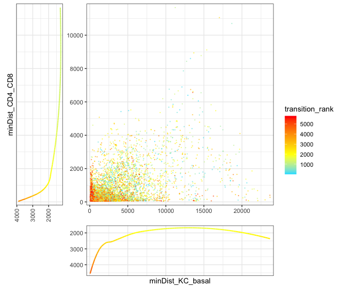

```r
df.plot <- df.mc[!is.na(df.mc$minDist_KC_basal) &
                 !is.na(df.mc$minDist_CD4_CD8) &
                 !is.na(df.mc$transition_rank), ]

plotWithMargin(
  df.plot,
  x.by     = "minDist_KC_basal",
  y.by     = "minDist_CD4_CD8",
  color.by = "transition_rank"
)
```

In this plot: - **Bottom-left corner**: MC_CD14 cells near both the epidermis and immune aggregates - **Bottom-right**: cells far from the epidermis but near immune aggregates (deep dermis) - **Top-left**: cells near the epidermis but far from immune aggregates (superficial dermis) - The **margin panels** show the loess trend of transition rank along each axis — if the transition is spatially organized, the loess curve will show a gradient

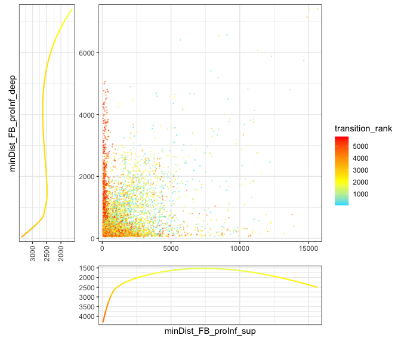

```r
df.plot <- df.mc[!is.na(df.mc$minDist_FB_proInf_sup) &
                 !is.na(df.mc$minDist_FB_proInf_deep) &
                 !is.na(df.mc$transition_rank), ]

plotWithMargin(
  df.plot,
  x.by     = "minDist_FB_proInf_sup",
  y.by     = "minDist_FB_proInf_deep",
  color.by = "transition_rank"
)
```

### Customizing colors

```r
# Green-to-red scale
plotWithMargin(
  df.plot,
  x.by     = "minDist_KC_basal",
  y.by     = "minDist_CD4_CD8",
  color.by = "transition_rank",
  cols     = c("green", "yellow", "orange", "red")
)
```

### Per-slide analysis

You can run the same analysis for each slide individually to check for consistency or slide-specific patterns:

```r
image.names <- unique(srt$Sample)

for (image.name in image.names) {
  df.tmp <- df.plot[df.plot$Sample == image.name, ]
  if (nrow(df.tmp) < 10) next

  p <- plotWithMargin(
    df.tmp,
    x.by     = "minDist_KC_basal",
    y.by     = "minDist_CD4_CD8",
    color.by = "transition_rank"
  )
  ggsave(paste0("minDist_MC_CD14_KC_basal_CD4CD8_", image.name, ".pdf"),
         plot = p, width = 7, height = 6)
}
```

## Putting it all together

Here is the complete workflow in a compact script:

```r
library(Seurat)
library(scSpatial)

# ---- Load data ----
srt <- readRDS("path/to/seurat.rds")
celltype.col <- "CellType"

# ---- Step 1: Compute minimum distances ----
dist.values <- calcMinDistance(
  srt,
  celltype.col  = celltype.col,
  ref.celltypes = list(
    KC_basal       = c("KC_basal"),
    CD4_CD8        = c("CD4", "CD8"),
    FB_proInf_sup  = c("FB_proInf_sup"),
    FB_proInf_deep = c("FB_proInf_deep")
  )
)

# Save results
write.csv(dist.values, "min_distance_values.csv")

# ---- Step 2: Add to metadata & subset ----
for (col in colnames(dist.values)) {
  srt@meta.data[[paste0("minDist_", col)]] <- dist.values[colnames(srt), col]
}

df.mc <- srt@meta.data[srt@meta.data[[celltype.col]] == "MC_CD14", ]

# ---- Step 3: Single-structure plots ----
ggplot(df.mc, aes(x = subCellType.pub1.1, y = minDist_KC_basal,
                  fill = subCellType.pub1.1)) +
  geom_violin() + geom_boxplot(width = 0.15) +
  theme_bw() + theme(axis.text.x = element_text(angle = 45, hjust = 1))

# ---- Step 4: Two-structure plots ----
plotWithMargin(df.mc,
               x.by = "minDist_KC_basal", y.by = "minDist_CD4_CD8",
               color.by = "transition_rank")
ggsave("minDist_KC_basal_vs_CD4CD8.pdf", width = 7, height = 6)

plotWithMargin(df.mc,
               x.by = "minDist_FB_proInf_sup", y.by = "minDist_FB_proInf_deep",
               color.by = "transition_rank")
ggsave("minDist_FB_proInf_sup_vs_deep.pdf", width = 7, height = 6)
```